# Bilingual Predictive Modeling: SwiftKey Milestone Report (EN & DE)

Altamash Ali

January 26, 2026

[figure not shown]

Auf Deutsch wechseln

# Executive Summary

### Project Goal

To explore the HC Corpora dataset (Blogs, News, and Twitter) and establish a foundation for a high-performance next-word prediction algorithm.

### Key Findings

# Data Statistics

Before cleaning, I analyzed the raw files to understand their scale. The volume of data requires an efficient sampling strategy to maintain sub-second prediction latency in the final product.

```r
file_size_blogs <- file.info("en_US.blogs.txt")$size / 1024^2
file_size_news <- file.info("en_US.news.txt")$size / 1024^2
file_size_twitter <- file.info("en_US.twitter.txt")$size / 1024^2

blogs <- readLines("en_US.blogs.txt", encoding = "UTF-8", skipNul = TRUE)
news <- readLines("en_US.news.txt", encoding = "UTF-8", skipNul = TRUE)
twitter <- readLines("en_US.twitter.txt", encoding = "UTF-8", skipNul = TRUE)

summary_table <- data.frame(
    File = c("Blogs", "News", "Twitter"),
    Size_MB = c(file_size_blogs, file_size_news, file_size_twitter),
    Line_Count = c(length(blogs), length(news), length(twitter)),
    Word_Count = c(sum(stri_count_words(blogs)), sum(stri_count_words(news)), sum(stri_count_words(twitter)))
)

kable(summary_table, caption = "Summary of Raw Data Files (English US)", digits = 2)
```

Summary of Raw Data Files (English US)

| File | Size_MB | Line_Count | Word_Count |
| --- | --- | --- | --- |
| Blogs | 200.42 | 899288 | 37546806 |
| News | 196.28 | 77259 | 2674561 |
| Twitter | 159.36 | 2360148 | 30096690 |

# Data Cleaning & Sampling

To ensure the algorithm remains fast and responsive, I extracted a 1% random sample. The cleaning pipeline included: conversion to lowercase, removal of punctuation and numbers, and filtering of excess white space.

```r
set.seed(1234)
sample_data <- c(sample(blogs, length(blogs) * 0.01),
                 sample(news, length(news) * 0.01),
                 sample(twitter, length(twitter) * 0.01))

sample_df <- data.frame(text = sample_data, stringsAsFactors = FALSE)
```

# Exploratory Analysis

I analyzed N-grams, which are sequences of words. This identifies the probability of word transitions—the core logic of my predictor.

### Top Bigrams (Two-Word Pairs)

Bigrams are the foundation of my next-word prediction. For example, the model identifies “of the” and “in the” as highly frequent anchors.

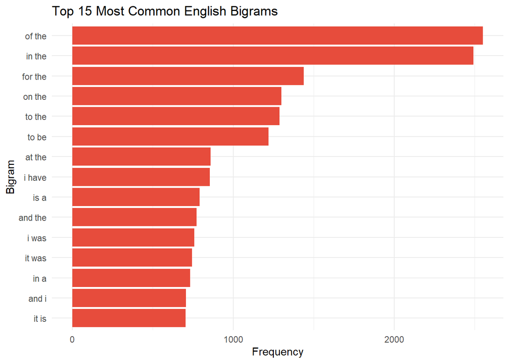

```r
bigrams <- sample_df %>%
    unnest_tokens(bigram, text, token = "ngrams", n = 2) %>%
    count(bigram, sort = TRUE) %>%
    top_n(15, n)

ggplot(bigrams, aes(x = reorder(bigram, n), y = n)) +
    geom_col(fill = "#e74c3c") +
    coord_flip() +
    labs(title = "Top 15 Most Common English Bigrams", x = "Bigram", y = "Frequency") +
    theme_minimal()
```

# Modeling Strategy

### 1. The Algorithm

I will implement a Katz Back-off model.

- `Trigram Match :` System first looks for a match based on the last two words typed.
- `Bigram Match :` If no trigram is found, it “backs off” to a one-word match.
- `Unigram Match :` Fallback to the most frequent word in the corpus.

### 2. Performance Optimization

- `Pruning :` Remove N-grams that appear only once (singletons).
- `Data Structure :` Use .rds files for fast loading and low memory footprint.

### Source Code

The full source code for this project and the final Shiny Application is available on GitHub: [View Source on GitHub](https://github.com/realAltamashAli/bilingual-swiftkey-nlp)